# Assignment Data Science Studio

```python
#Dependencies
import pandas as pd
import numpy as np
from sqlalchemy import create_engine
import seaborn as sns
import matplotlib.pyplot as plt
from numpy import exp, log1p, sqrt
```

## 1. Introduction

The project is dedicated to explore and analyse the Used car Prices dataset through unsupervised and supervised machine learning techniques. The selected dataset is second hand car prices for Barcelona province in 2022. It was retrieved from Kaggle and originally comes from zenodo.org. The dataset has 9 characteristics and 790 cars (observations).  
The project consists of the following steps: data wrangling & exploratory data analysis, clustering and supervised learning. Every step is followed with the explanation of the procedure, analysis of results and their implications.

## 2. Data wrangling and EDA

The dataset contains 9 variables (exluding ID) related to the car advertised. There are 6 categorical variables - brand, model, engine, fuel, gearbox and location, and 3 continuous - price in euro, production year, mileage in km.

```python
# Read data
db = pd.read_csv("https://github.com/mira7991/data_science_studio_assignment/raw/main/data/used_cars.csv.zip")
#db.head()
```

Data cleaning consist of (1) renaming of variables for future clean visualizations, (2) dropping variables of no interest, (3) dropping rows with NA values and (4) saving cleaned dataset. We drop engine (694 categories) and car model (206 categories) since they are more unique information and possibly would not be very useful for further analysis of clustering and prediction.

```python
db = db.rename(columns={"Unnamed: 0": "id", 'brand': 'Brand', 'price (eur)': 'Price', 'year':'Year',
                        'mileage (kms)':'Mileage', 'fuel':'Fuel', 'gearbox':'Gearbox', 'location': 'Location'})
print( "Car model categories:" , db.model.unique().shape)
print( "Car engine categories:" ,db.engine.unique().shape)
db = db.drop(['engine', 'model'], axis=1)
db = db.dropna()
db = db.set_index("id")
db.to_csv("used_cars_cleaned.csv")
# db.head()
```

```
Car model categories: (206,)
Car engine categories: (694,)
```

### Distribution of the variables

The mean value for the car price is €15973, the average year of their production is 2016 and average mileage corressponds to 83229 km. It is clear from the information below that car price and mileage varies significantly, €6984 and 46202 kilometers respectfully, while the production varies by 2,5 years.

```python
db.describe().T
```

|  | count | mean | std | min | 25% | 50% | 75% | max |
| --- | --- | --- | --- | --- | --- | --- | --- | --- |
| Price | 792.0 | 15973.383838 | 6984.338370 | 4990.0 | 11355.0 | 14990.0 | 18490.00 | 82580.0 |
| Year | 792.0 | 2016.404040 | 2.452251 | 2004.0 | 2015.0 | 2017.0 | 2018.00 | 2021.0 |
| Mileage | 792.0 | 83228.833333 | 46202.118589 | 1258.0 | 47145.5 | 80065.5 | 116321.75 | 220000.0 |

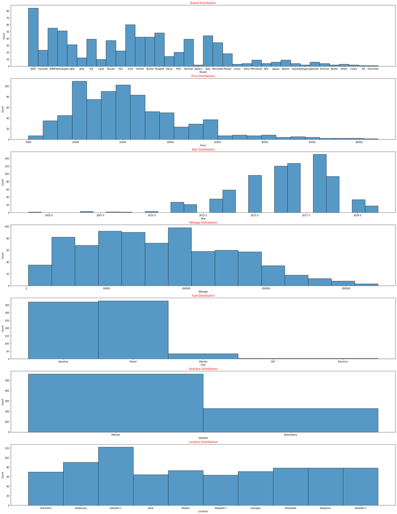

```python
def histograms_plot(dataframe, columns, rows, cols):
    fig=plt.figure(figsize=(30, 40))
    for i, col in enumerate(columns):
        ax=fig.add_subplot(rows,cols,i+1)
        sns.histplot(dataframe, x=col)
        ax.set_title(col+" Distribution",color='red')

    # plt.show()

histograms_plot(db, db.columns, 7,1)
```

As previously mentioned the price range varies significantly which is also clear from the histogram. The main reason is outliers - cars with very high price tag. It is decided to eliminate these cars from our further analysis due to their low number (5 cars).

```python
db[db['Price']>45000].shape[0]
```

```
5
```

```python
db = db[db['Price']<45000]
```

### Analysing Relationships between variables

At first, before clustering, it is interesting to see the relationships between the different characteristics.The scatter plots below show relationships between different continuous variables. It is obvious that the the newer the car the less is the mileage. It is also depicted that the newer the car, the higher the price. There is almost no association between the mileage and the price,it is a very slight relationship that can be observed - the less is the mileage, the more expensive is the car.

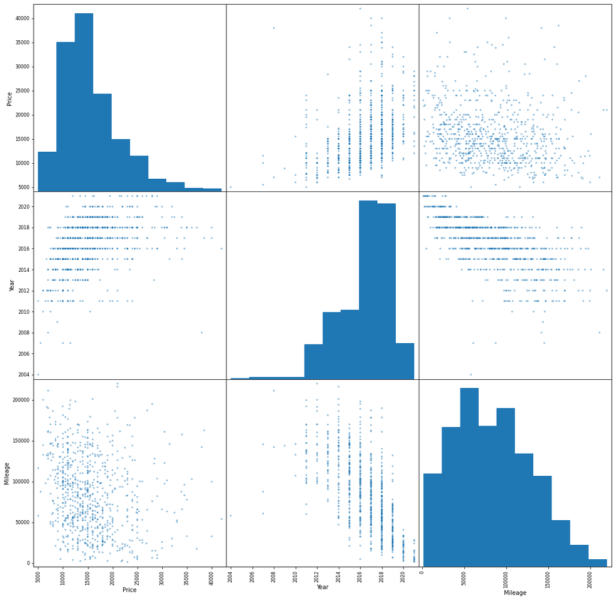

```python
pd.plotting.scatter_matrix(db,
                               figsize=(18, 18));
```

The correlation matric supports above-mentioned visual analysis of scatterplots.

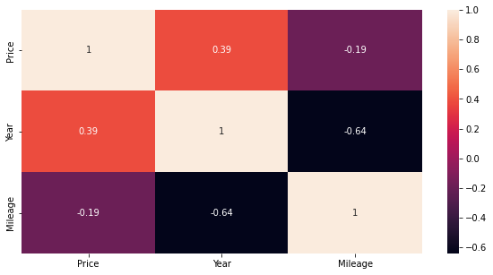

```python
correlation = db.corr(numeric_only=True).round(2)
plt.figure(figsize = (10, 5))
sns.heatmap(correlation, annot = True)
```

The most expensive brands by the average price are Cupra, Jaguar and Porsche, which is reasonable since they are all premium class type. While most of the used cars on Barcelona province market are manual, the higher priced ones are on automatic gearbox. Hybrid cars are more expensive probably given more complicated technology. Esplugas is the market that has most expensive cars on average.

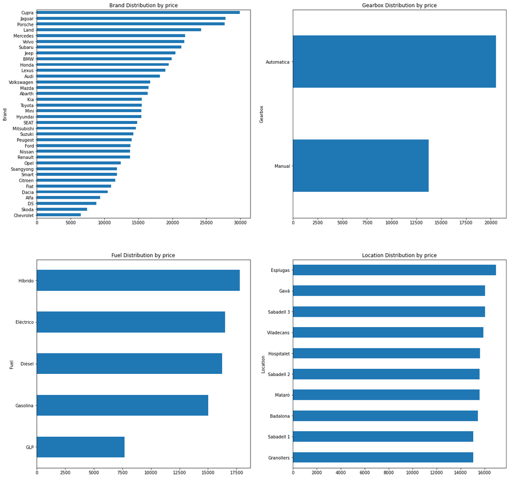

```python
def bar_plot_by_price(dataframe, columns, rows, cols):
    fig=plt.figure(figsize=(20, 20))
    for i, col in enumerate(columns):
        grouped=db.groupby(col)["Price"].mean().sort_values()
        ax=fig.add_subplot(rows,cols,i+1)
        grouped.plot.barh()
        ax.set_title(col+" Distribution by price")


bar_plot_by_price(db, ['Brand','Gearbox','Fuel', 'Location'], 2,2)
```

## 3. Unsupervised learning

The goal of the clustering is to find groups with similar patterns. It can be used for further data analysis. For example, this can be useful for costumers and business to understand most common characteristics of the used cars in the clustered price range.

```python
from numpy.random import seed

from sklearn.cluster import KMeans
from sklearn.metrics import silhouette_score, calinski_harabasz_score
from sklearn.decomposition import PCA
from sklearn.preprocessing import scale, MinMaxScaler
```

#### One hot encoding

In order for all the variables to be used in clustering, categorical variables should be converted to numerical using one hot encoding.

```python
db_2 = pd.get_dummies(db)
db_2.loc[1]
```

```
Price                    9990
Year                     2014
Mileage                104868
Brand_Abarth                0
Brand_Alfa                  0
Brand_Audi                  0
Brand_BMW                   0
Brand_Chevrolet             0
Brand_Citroen               0
Brand_Cupra                 0
Brand_DS                    0
Brand_Dacia                 0
Brand_Fiat                  0
Brand_Ford                  0
Brand_Honda                 0
Brand_Hyundai               1
Brand_Jaguar                0
Brand_Jeep                  0
Brand_Kia                   0
Brand_Land                  0
Brand_Lexus                 0
Brand_Mazda                 0
Brand_Mercedes              0
Brand_Mini                  0
Brand_Mitsubishi            0
Brand_Nissan                0
Brand_Opel                  0
Brand_Peugeot               0
Brand_Porsche               0
Brand_Renault               0
Brand_SEAT                  0
Brand_Skoda                 0
Brand_Smart                 0
Brand_Ssangyong             0
Brand_Subaru                0
Brand_Suzuki                0
Brand_Toyota                0
Brand_Volkswagen            0
Brand_Volvo                 0
Fuel_Diésel                 1
Fuel_Eléctrico              0
Fuel_GLP                    0
Fuel_Gasolina               0
Fuel_Híbrido                0
Gearbox_Automatica          0
Gearbox_Manual              1
Location_Badalona           0
Location_Esplugas           0
Location_Gavá               0
Location_Granollers         0
Location_Hospitalet         0
Location_Mataró             0
Location_Sabadell 1         0
Location_Sabadell 2         0
Location_Sabadell 3         0
Location_Viladecans         1
Name: 1, dtype: int64
```

#### Building models

The three clustering models were built using K-means technique based on (1) raw values, (2) standardized values and (3) using Principal Component Analysis.

```python
# 1. Raw values clustering

seed(12345)
estimator = KMeans(n_clusters = 5)
estimator.fit(db_2)
k5_raw = pd.Series(estimator.labels_, index=db_2.index)
# k5_raw.head()
```

```
id
0    1
1    0
2    3
3    1
4    1
dtype: int32
```

```python
# 2. Standardized values clustering

seed(12345)
db_stdev = scale(db_2)
estimator = KMeans(n_clusters = 5)
estimator.fit(db_stdev)
k5_std = pd.Series(estimator.labels_, index=db_2.index)
# k5_std.head()
```

```
id
0    1
1    2
2    3
3    1
4    1
dtype: int32
```

```python
# 3.PCA values clustering

seed(12345)
pca_estimator = PCA(n_components=2)
pca_estimator
components = pca_estimator.fit_transform(db_2)
components = pd.DataFrame(components,
                              index = db_2.index,
                              columns = ["C-1", "C-2"]
                             )
# clustering
estimator = KMeans(n_clusters = 5)
estimator.fit(components)
k5_pca = pd.Series(estimator.labels_,index=components.index)
# k5_pca.head()
```

```
id
0    2
1    1
2    4
3    2
4    2
dtype: int32
```

#### Visual analysis

Given that PCA values are simply linear combinations of the characteristics from the original data, it is clear from the plots of the cluster on the C1-C2 surface that the raw data and PCA values are clustered in the same way. On the other hand, standardised values are clustered quite differently, making it difficult to visually distinguish between 5 groups.

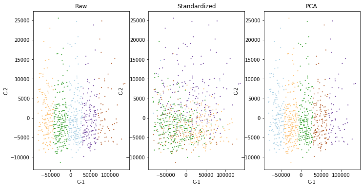

```python
f, axs = plt.subplots(1, 3, figsize=(12, 6))

ax = axs[0]
components.assign(labels=k5_raw)\
          .plot.scatter("C-1",
                        "C-2",
                        c="labels",
                        s=1,
                        cmap="Paired",
                        colorbar=False,
                        ax=ax
                       )
ax.set_title("Raw")

ax = axs[1]
components.assign(labels=k5_std)\
          .plot.scatter("C-1",
                        "C-2",
                        c="labels",
                        s=1,
                        cmap="Paired",
                        colorbar=False,
                        ax=ax
                       )
ax.set_title("Standardized")

ax = axs[2]
components.assign(labels=k5_pca)\
          .plot.scatter("C-1",
                        "C-2",
                        c="labels",
                        s=1,
                        cmap="Paired",
                        colorbar=False,
                        ax=ax
                       )
ax.set_title("PCA")



plt.show()
```

#### Quality check

Most common ways to assess the quality of clustering is using Calinski and Harabasz (C&H) score that shows the ratio of between over within dispersion. Raw values and PCA values clustering show significantly higher identical values compared to clustering of standardized values. It implies that former two are better models than the latter.

```python
chs_raw = calinski_harabasz_score(db_2,
                                  k5_raw
                                 )
chs_std = calinski_harabasz_score(db_2,
                                  k5_std
                                 )
chs_pca = calinski_harabasz_score(db_2,
                                  k5_pca
                                 )
pd.Series({"Raw": chs_raw,
            "Standardised": chs_std,
            "PCA": chs_pca,
              })
```

```
Raw             2600.340859
Standardised      64.634933
PCA             2599.866175
dtype: float64
```

Silhouette scores show that the PCA values clustering is best K-means model. It is slightly better than the one with the raw values.

```python
%%time
sil_raw = silhouette_score(db_2,
                           k5_raw,
                           metric="euclidean"
                          )

sil_std = silhouette_score(db_2,
                           k5_std,
                           metric="euclidean"
                          )

sil_pca = silhouette_score(db_2,
                           k5_pca,
                           metric="euclidean"
                          )

pd.Series({"Raw": sil_raw,
               "Standardised": sil_std,
               "PCA": sil_pca,
              })
```

```
CPU times: total: 109 ms
Wall time: 106 ms
```

```
Raw             0.493906
Standardised   -0.069593
PCA             0.494209
dtype: float64
```

#### Optimizing number of clusters and choosing the model

The number of cluster in K-means can be optimized using C&H score. According to the line graph, the best K-means model with raw values has 10 clusters. Here, the choice of model depends on whether more complexity is desired. The difference is not big, so the K-means clustering with 5 clusters of raw values is the preferred model. Even though PCA reduces dimensions and complexity of the model, it is not easily interpretable, thus hard to tell the story. The choice always depends on the goal of the work, here, explore interesting patterns from the clustering.

```python
%%time
seed(12345)

chss = {}
for i in [2, 5, 10, 15, 20, 30]:
    estimator = KMeans(n_clusters=i)
    estimator.fit(components)
    chs = calinski_harabasz_score(db_2,
                                  estimator.labels_
                                 )
    chss[i] = chs
chss = pd.Series(chss)
```

```
CPU times: total: 9.72 s
Wall time: 2.49 s
```

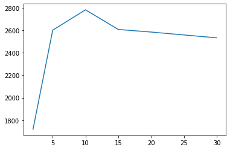

```python
chss.plot.line()
```

Each cluster has between 66 and 219 cars.

```python
# counting how many cars in each cluster
g = db_2\
      .groupby(k5_raw)
g.size()\
 .sort_values()
```

```
4     66
3    145
2    160
0    197
1    219
dtype: int64
```

#### Exploring the average characteristics of the cluster

```python
g.mean().T
```

|  | 0 | 1 | 2 | 3 | 4 |
| --- | --- | --- | --- | --- | --- |
| Price | 15382.335025 | 15667.305936 | 18054.25000 | 14007.448276 | 14714.545455 |
| Year | 2015.918782 | 2016.986301 | 2018.77500 | 2014.572414 | 2014.030303 |
| Mileage | 94796.888325 | 58500.963470 | 23628.28750 | 131350.779310 | 172018.863636 |
| Brand_Abarth | 0.010152 | 0.022831 | 0.01250 | 0.000000 | 0.000000 |
| Brand_Alfa | 0.005076 | 0.009132 | 0.00000 | 0.006897 | 0.000000 |
| Brand_Audi | 0.055838 | 0.022831 | 0.02500 | 0.124138 | 0.090909 |
| Brand_BMW | 0.076142 | 0.022831 | 0.03750 | 0.117241 | 0.181818 |
| Brand_Chevrolet | 0.005076 | 0.000000 | 0.00000 | 0.000000 | 0.000000 |
| Brand_Citroen | 0.025381 | 0.063927 | 0.06250 | 0.062069 | 0.060606 |
| Brand_Cupra | 0.000000 | 0.000000 | 0.01250 | 0.000000 | 0.000000 |
| Brand_DS | 0.005076 | 0.000000 | 0.00000 | 0.000000 | 0.000000 |
| Brand_Dacia | 0.020305 | 0.013699 | 0.04375 | 0.000000 | 0.000000 |
| Brand_Fiat | 0.025381 | 0.036530 | 0.03125 | 0.013793 | 0.030303 |
| Brand_Ford | 0.050761 | 0.086758 | 0.13125 | 0.055172 | 0.030303 |
| Brand_Honda | 0.015228 | 0.004566 | 0.00625 | 0.000000 | 0.015152 |
| Brand_Hyundai | 0.020305 | 0.050228 | 0.03125 | 0.006897 | 0.030303 |
| Brand_Jaguar | 0.005076 | 0.013699 | 0.00625 | 0.000000 | 0.015152 |
| Brand_Jeep | 0.010152 | 0.009132 | 0.03125 | 0.013793 | 0.015152 |
| Brand_Kia | 0.045685 | 0.059361 | 0.07500 | 0.027586 | 0.015152 |
| Brand_Land | 0.015228 | 0.009132 | 0.00625 | 0.020690 | 0.015152 |
| Brand_Lexus | 0.010152 | 0.004566 | 0.00000 | 0.000000 | 0.000000 |
| Brand_Mazda | 0.030457 | 0.013699 | 0.03125 | 0.006897 | 0.045455 |
| Brand_Mercedes | 0.055838 | 0.050228 | 0.00000 | 0.055172 | 0.060606 |
| Brand_Mini | 0.010152 | 0.022831 | 0.03125 | 0.041379 | 0.030303 |
| Brand_Mitsubishi | 0.020305 | 0.009132 | 0.00625 | 0.000000 | 0.030303 |
| Brand_Nissan | 0.040609 | 0.031963 | 0.05000 | 0.075862 | 0.045455 |
| Brand_Opel | 0.045685 | 0.050228 | 0.04375 | 0.013793 | 0.030303 |
| Brand_Peugeot | 0.116751 | 0.045662 | 0.04375 | 0.055172 | 0.000000 |
| Brand_Porsche | 0.000000 | 0.000000 | 0.00000 | 0.006897 | 0.045455 |
| Brand_Renault | 0.045685 | 0.068493 | 0.05625 | 0.027586 | 0.030303 |
| Brand_SEAT | 0.106599 | 0.132420 | 0.10625 | 0.089655 | 0.060606 |
| Brand_Skoda | 0.000000 | 0.004566 | 0.00000 | 0.006897 | 0.000000 |
| Brand_Smart | 0.000000 | 0.013699 | 0.00000 | 0.000000 | 0.000000 |
| Brand_Ssangyong | 0.005076 | 0.004566 | 0.00000 | 0.000000 | 0.000000 |
| Brand_Subaru | 0.005076 | 0.000000 | 0.00625 | 0.000000 | 0.000000 |
| Brand_Suzuki | 0.010152 | 0.009132 | 0.00000 | 0.000000 | 0.000000 |
| Brand_Toyota | 0.050761 | 0.054795 | 0.05000 | 0.062069 | 0.045455 |
| Brand_Volkswagen | 0.055838 | 0.050228 | 0.05625 | 0.103448 | 0.075758 |
| Brand_Volvo | 0.000000 | 0.009132 | 0.00625 | 0.006897 | 0.000000 |
| Fuel_Diésel | 0.573604 | 0.305936 | 0.16875 | 0.772414 | 0.878788 |
| Fuel_Eléctrico | 0.005076 | 0.009132 | 0.00000 | 0.000000 | 0.000000 |
| Fuel_GLP | 0.000000 | 0.000000 | 0.00000 | 0.013793 | 0.030303 |
| Fuel_Gasolina | 0.375635 | 0.630137 | 0.78125 | 0.193103 | 0.075758 |
| Fuel_Híbrido | 0.045685 | 0.054795 | 0.05000 | 0.020690 | 0.015152 |
| Gearbox_Automatica | 0.319797 | 0.219178 | 0.25000 | 0.324138 | 0.454545 |
| Gearbox_Manual | 0.680203 | 0.780822 | 0.75000 | 0.675862 | 0.545455 |
| Location_Badalona | 0.106599 | 0.095890 | 0.15000 | 0.041379 | 0.090909 |
| Location_Esplugas | 0.086294 | 0.082192 | 0.10000 | 0.089655 | 0.106061 |
| Location_Gavá | 0.076142 | 0.086758 | 0.07500 | 0.096552 | 0.060606 |
| Location_Granollers | 0.086294 | 0.082192 | 0.08750 | 0.103448 | 0.090909 |
| Location_Hospitalet | 0.065990 | 0.155251 | 0.08750 | 0.068966 | 0.106061 |
| Location_Mataró | 0.101523 | 0.082192 | 0.11250 | 0.082759 | 0.075758 |
| Location_Sabadell 1 | 0.131980 | 0.141553 | 0.11875 | 0.220690 | 0.212121 |
| Location_Sabadell 2 | 0.101523 | 0.059361 | 0.09375 | 0.075862 | 0.060606 |
| Location_Sabadell 3 | 0.116751 | 0.073059 | 0.08750 | 0.124138 | 0.106061 |
| Location_Viladecans | 0.126904 | 0.141553 | 0.08750 | 0.096552 | 0.090909 |

```python
# Using the below code we can identify to which cluster the car belongs and its features
tidy_db = db_2\
            .stack()\
            .reset_index()\
            .rename(columns={"level_1": "Var",
                             "level_0": "ID",
                             0: "Value"
                            })\
            .join(pd.DataFrame({"Label": k5_raw}),
                  on="id")
tidy_db.loc[tidy_db['id']==0,:]
```

|  | id | Var | Value | Label |
| --- | --- | --- | --- | --- |
| 0 | 0 | Price | 8990 | 1 |
| 1 | 0 | Year | 2016 | 1 |
| 2 | 0 | Mileage | 67000 | 1 |
| 3 | 0 | Brand_Abarth | 0 | 1 |
| 4 | 0 | Brand_Alfa | 0 | 1 |
| 5 | 0 | Brand_Audi | 0 | 1 |
| 6 | 0 | Brand_BMW | 0 | 1 |
| 7 | 0 | Brand_Chevrolet | 0 | 1 |
| 8 | 0 | Brand_Citroen | 0 | 1 |
| 9 | 0 | Brand_Cupra | 0 | 1 |
| 10 | 0 | Brand_DS | 0 | 1 |
| 11 | 0 | Brand_Dacia | 0 | 1 |
| 12 | 0 | Brand_Fiat | 0 | 1 |
| 13 | 0 | Brand_Ford | 0 | 1 |
| 14 | 0 | Brand_Honda | 0 | 1 |
| 15 | 0 | Brand_Hyundai | 0 | 1 |
| 16 | 0 | Brand_Jaguar | 0 | 1 |
| 17 | 0 | Brand_Jeep | 0 | 1 |
| 18 | 0 | Brand_Kia | 0 | 1 |
| 19 | 0 | Brand_Land | 0 | 1 |
| 20 | 0 | Brand_Lexus | 0 | 1 |
| 21 | 0 | Brand_Mazda | 0 | 1 |
| 22 | 0 | Brand_Mercedes | 0 | 1 |
| 23 | 0 | Brand_Mini | 0 | 1 |
| 24 | 0 | Brand_Mitsubishi | 0 | 1 |
| 25 | 0 | Brand_Nissan | 0 | 1 |
| 26 | 0 | Brand_Opel | 0 | 1 |
| 27 | 0 | Brand_Peugeot | 0 | 1 |
| 28 | 0 | Brand_Porsche | 0 | 1 |
| 29 | 0 | Brand_Renault | 0 | 1 |
| 30 | 0 | Brand_SEAT | 1 | 1 |
| 31 | 0 | Brand_Skoda | 0 | 1 |
| 32 | 0 | Brand_Smart | 0 | 1 |
| 33 | 0 | Brand_Ssangyong | 0 | 1 |
| 34 | 0 | Brand_Subaru | 0 | 1 |
| 35 | 0 | Brand_Suzuki | 0 | 1 |
| 36 | 0 | Brand_Toyota | 0 | 1 |
| 37 | 0 | Brand_Volkswagen | 0 | 1 |
| 38 | 0 | Brand_Volvo | 0 | 1 |
| 39 | 0 | Fuel_Diésel | 0 | 1 |
| 40 | 0 | Fuel_Eléctrico | 0 | 1 |
| 41 | 0 | Fuel_GLP | 0 | 1 |
| 42 | 0 | Fuel_Gasolina | 1 | 1 |
| 43 | 0 | Fuel_Híbrido | 0 | 1 |
| 44 | 0 | Gearbox_Automatica | 0 | 1 |
| 45 | 0 | Gearbox_Manual | 1 | 1 |
| 46 | 0 | Location_Badalona | 0 | 1 |
| 47 | 0 | Location_Esplugas | 0 | 1 |
| 48 | 0 | Location_Gavá | 0 | 1 |
| 49 | 0 | Location_Granollers | 1 | 1 |
| 50 | 0 | Location_Hospitalet | 0 | 1 |
| 51 | 0 | Location_Mataró | 0 | 1 |
| 52 | 0 | Location_Sabadell 1 | 0 | 1 |
| 53 | 0 | Location_Sabadell 2 | 0 | 1 |
| 54 | 0 | Location_Sabadell 3 | 0 | 1 |
| 55 | 0 | Location_Viladecans | 0 | 1 |

```python
# save model
pd.DataFrame({"k10_raw": k5_raw})\
      .to_parquet("./data/k10_raw.parquet")
```

#### Limitations

For the building clustering models only K-means technique was used. K-means model is good for numerical data as it calculates Euclidean distance. However, since the dataset contains both continuous and categorical data, it would've been more appropriate to use K-prototypes. This algorithm integrates k-modes and k-means and is able to group mixed continuous and categorical data.

## 3. Supervised learning

Linear regression model is type of supervised learning technique which can be used to predict continuous variable. It is based on the idea of reducing residual sum of squares between predicted and observed value. For this task, the price is be the predicted value while the rest of the variables are used to build the linear regression model. Since the Price is skewed (skew=1.2) variable we will use log of Price(skew=0.1).

```python
skew = pd.Series({'Price skew':db_2["Price"].skew(),'log Price skew': np.log1p(db_2['Price']).skew()})
skew
```

```
Price skew        1.203432
log Price skew    0.115870
dtype: float64
```

```python
log_price = np.log1p(db_2["Price"])
```

```python
# Dropping categorical variables that would be at intercept, chosen randomly
db_2 = db_2.drop(["Brand_Abarth", "Fuel_Diésel","Gearbox_Automatica","Location_Badalona"],
                                     axis=1)
```

#### Building Linear Regression Model (Ordinary Least Squares)

```python
from sklearn.linear_model import LinearRegression

X = db_2.drop(['Price'], axis=1)
regressor = LinearRegression()
regressor.fit(X, log_price)
predicted_val = regressor.predict(X)
# predicted_val
```

#### The coefficients of the model

Since there are 51 variables, not all of them will be explained. The general idea is that the regression coefficients with positive/negative sign has the positive/negative association with the predicted variable. For instance, the later is production year, the more expensive is the car, while if the car is of Alfa brand, probably it is less expensive. Also, need to be mentioned, the coefficients are not having strong associations.

```python
pd.Series(regressor.coef_,
              index=X.columns
             )
```

```
Year                   0.074625
Mileage               -0.000001
Brand_Alfa            -0.402325
Brand_Audi             0.130190
Brand_BMW              0.138464
Brand_Chevrolet       -0.346180
Brand_Citroen         -0.293566
Brand_Cupra            0.303931
Brand_DS              -0.436070
Brand_Dacia           -0.406204
Brand_Fiat            -0.338617
Brand_Ford            -0.187971
Brand_Honda            0.279444
Brand_Hyundai         -0.018655
Brand_Jaguar           0.275640
Brand_Jeep             0.195798
Brand_Kia             -0.103502
Brand_Land             0.340228
Brand_Lexus           -0.030924
Brand_Mazda            0.011399
Brand_Mercedes         0.222883
Brand_Mini            -0.026884
Brand_Mitsubishi      -0.001953
Brand_Nissan          -0.121078
Brand_Opel            -0.228221
Brand_Peugeot         -0.175539
Brand_Porsche          0.661323
Brand_Renault         -0.197222
Brand_SEAT            -0.089714
Brand_Skoda           -0.543548
Brand_Smart           -0.364159
Brand_Ssangyong       -0.054774
Brand_Subaru           0.011249
Brand_Suzuki          -0.176877
Brand_Toyota          -0.126906
Brand_Volkswagen       0.026568
Brand_Volvo            0.155844
Fuel_Eléctrico        -0.157363
Fuel_GLP              -0.402576
Fuel_Gasolina         -0.089057
Fuel_Híbrido          -0.165786
Gearbox_Manual        -0.267660
Location_Esplugas      0.076554
Location_Gavá          0.075447
Location_Granollers    0.035358
Location_Hospitalet    0.044872
Location_Mataró        0.042295
Location_Sabadell 1    0.039981
Location_Sabadell 2    0.058957
Location_Sabadell 3    0.048065
Location_Viladecans    0.040774
dtype: float64
```

The intercept is interpreted as the log of price when all continuous variables(Mileage, Year) set to zero and categoricals are default Brand_Abarth, Fuel_Diésel,Gearbox_Automatica,Location_Badalona. It doesn't have to correspond to realistic scenario.

```python
regressor.intercept_
```

```
-140.5278753539258
```

#### Evaluation of the predictive performance

Predictive performance without cross validation. Three quality metrics were used to evaluate the performance with and without cross validation: Mean Absolute Error (MAE), Root Mean Squared Error (RMSE) and R-squared. MAE shows the average of the absolute difference between the observed and predicted values. RMSE calculates the standard deviation of residuals. R-squared shows the proportion of the variability that can be explained by the model. Since former two gives results in the same unit as the variable, it is better to see them in real price than log price. Therefore, the Price variable and converted predicted values are used for the evaluation.

The model produces results of quite low quality. It can only explain 15% of the variation in price prediction. MAE and RMSE both quantify the average difference in errors, where the first is linear and the second is quadratic. As a result, the latter penalises significant errors more severely. These metrics indicate high model errors, 3925 and 5519 Euro, respectively.

```python
from sklearn import metrics

perf = pd.Series({'MAE': metrics.mean_absolute_error( db_2['Price'],
                                                           np.expm1(yp_log)),
                         'RMSE': sqrt(metrics.mean_squared_error( db_2['Price'],
                                                           np.expm1(yp_log))),
                         'R^2': metrics.r2_score( db_2['Price'],
                                                           np.expm1(yp_log))})
perf
```

```
MAE     3925.049184
RMSE    5519.506453
R^2        0.150558
dtype: float64
```

To build the model with cross-validation, we need to split the dataset into train and test subsets and make the model learn on train subset.

```python
# Building model with Cross-validation

# Train/test split
from sklearn.model_selection import train_test_split

x_train, x_test, y_train, y_test = train_test_split(X,
                                                    log_price,
                                                    test_size=0.8
                                                   )

# Linear regression
lm_estimator = LinearRegression()
# Fit on X/Y train|
lm_estimator.fit(x_train, y_train)
# Predict on X test
test_y_pred = lm_estimator.predict(x_test)
```

```python
# Performance with cross-validation
perf_cv = pd.Series({'MAE': metrics.mean_absolute_error(np.expm1(y_test),
                                                            np.expm1(test_y_pred)),
                         'RMSE': sqrt(metrics.mean_squared_error(np.expm1(y_test),
                                                            np.expm1(test_y_pred))),
                         'R^2': metrics.r2_score(np.expm1(y_test),
                                                            np.expm1(test_y_pred))})
perf_cv
```

```
MAE     3102.046253
RMSE    4361.443485
R^2        0.490086
dtype: float64
```

The model with cross-validation shows better results than without. It shows that 49% of variablity in prediction of the price can be explained by the model and gives lower error metrics. The fact that it shows better performance may happen due to random splitting of training and testing subsets. It is recommended to use K-fold CV to get the mean of different random splittings that will ensure that we used all data(both from test and train) to evaluate the model.

```python
perf.df = pd.DataFrame({"performance without CV": perf,
                       "performance with CV": perf_cv
                       })
perf.df
```

|  | performance without CV | performance with CV |
| --- | --- | --- |
| MAE | 3925.049184 | 3102.046253 |
| RMSE | 5519.506453 | 4361.443485 |
| R^2 | 0.150558 | 0.490086 |

Using K-fold shows even better results - mean R-squared for 5 folds(groups) is 62.5%. Seems like the model after all is not that bad for prediction of the price for the used car.

```python
# K-fold CV
from sklearn.model_selection import cross_val_score

lm_kcv_r2 = cross_val_score(LinearRegression(),
                              X,
                              log_price,
                              cv=5,
                              scoring="r2"
                             )

lm_kcv_r2.mean()
```

```
0.6249969152141936
```